# Developing Different Forecasting Strategies for Different Type of Products

Osman Oguz Nuhoglu, Beste Yildiz Yilmaz, Efe Ahmet Guden - IE360 - Spring 2021

# Introduction

The aim of this homework is to develop alternative forecasting strategies for different products as in the final project. First, the time series of different products will be decomposed at different levels and the trend-cycle component and the seasonality effects will be analyzed. Then, several ARIMA models will be built and evaluated based on their performace on the training set. After building ARIMA models, several regressors will be added to the models. After adding regressors, ARIMA and ARIMAX will be compared based on their performance on a test period. The aim is to improve the model on the final project. All tasks will be performed separately for each product. Products are very different in nature but there are two main categories. The data for product 1,2, and 3 is only available after some point in time. This does not hold for the other products. We define decomposition function later on. One can see how we implement the function for these two main categories.

# Data Manipulation

In this homework, we use updated data, therefore the following chunk of code is enough for manipulation.

```r
data1[,price:=round(price,2)]
data1[,event_date:=as.Date(event_date, format = "%d/%m/%Y")]
data1 = data1[order(event_date, decreasing = FALSE)]
data = rbind(data1,data2)
data = data[event_date<"2021-07-01"]
head(data,10)
```

```
##      price event_date product_content_id sold_count visit_count favored_count
##  1:  79.34 2020-05-25              85004         36           0             0
##  2:  76.05 2020-05-25            4066298        142           0             0
##  3: 137.69 2020-05-25            6676673        539           0             0
##  4: 238.87 2020-05-25            7061886         39           0             0
##  5:  44.99 2020-05-25           31515569        610           0             0
##  6:  59.99 2020-05-25           32737302         40           0             0
##  7: 112.90 2020-05-25           32939029         74           0             0
##  8:     NA 2020-05-25           48740784          0           0             0
##  9:     NA 2020-05-25           73318567          0           0             0
## 10:  78.52 2020-05-26              85004         42           0             0
##     basket_count category_sold category_brand_sold category_visits ty_visits
##  1:          233           260                   0            4039         1
##  2:          307           413                   0            1149         1
##  3:         1783           674                   0           10271         1
```

[output cut: 18 more lines]

```r
tail(data,10)
```

```
##     price event_date product_content_id sold_count visit_count favored_count
##  1: 85.72 2021-06-21              85004         76        3088           601
##  2: 83.42 2021-06-22              85004         83        3248           399
##  3: 85.77 2021-06-23              85004         75        2517           292
##  4: 87.47 2021-06-24              85004         51        2072           246
##  5: 86.30 2021-06-25              85004         50        2108           292
##  6: 86.34 2021-06-26              85004         54        1823           245
##  7: 87.44 2021-06-27              85004         56        2463           303
##  8: 80.49 2021-06-28              85004         80        2852           326
##  9: 79.90 2021-06-29              85004        121        3136           359
## 10: 81.56 2021-06-30              85004         87        3063           401
##     basket_count category_sold category_brand_sold category_visits ty_visits
##  1:          320          4002                 570          161024 105665153
##  2:          475          2812                 338          121201  93946117
##  3:          334          2848                 336          117794  97696131
```

[output cut: 18 more lines]

As stated before, some of the variables will be added to models. But we cannot add all of them because some of them has flaws. For example, `visit_count`, `favored_count`, `category_brand_sold`, `ty_visits`, `category_basket` are not available for a part of the data. Also, `category_visits` is not stable over time, it has an obvious trend and it cannot be used. Lastly, `price` is not reliable either because when there is no sales, `price` turns out to be -1 which does not make any sense. Also using lagged price does not make sense because people does not consider price level of the past when they buy something.

```r
data[,c("visit_count","favored_count","category_brand_sold","ty_visits","category_basket"):=NULL]
data[,category_visits:=NULL]
data[,price:=NULL]
data[,lag_basket_count:=shift(basket_count,2)]
data[,lag_category_sold:=shift(category_sold,2)]
data[,lag_category_favored:=shift(category_favored,2)]
```

We split the data into 9 parts, each corresponding to different products.

```r
data_1 = data[product_content_id==48740784] #coat
data_2 = data[product_content_id==73318567] #bikini top 1
data_3 = data[product_content_id==32737302] #bikini top 2
data_4 = data[product_content_id==31515569] #tight
data_5 = data[product_content_id==6676673]  #headphones
data_6 = data[product_content_id==7061886]  #vacuum cleaner
data_7 = data[product_content_id==85004]    #face cleanser
data_8 = data[product_content_id==4066298]  #baby wipe
data_9 = data[product_content_id==32939029] #electric toothbrush
```

# Function Definitions

```r
decomp = function(data){
    daily = ts(data[,sold_count], freq=7)
    daily_decomp = decompose(daily)
    daily_decomp = list(trend=daily_decomp$trend, seasonal=daily_decomp$seasonal,
                        figure=daily_decomp$figure, random=daily_decomp$random)

    data[,t:=1:.N]
    data[,week:=floor(1+(t-1)/7)]
    weekly = data[, .(sold=mean(sold_count)), by=.(week=week)]
    weekly = weekly[, sold]
    weekly = ts(weekly, freq = 4)
    weekly_decomp = decompose(weekly)
    weekly_decomp = list(trend=weekly_decomp$trend, figure=weekly_decomp$figure)
    data[,c("t","week"):=NULL]

    monthly = data[, list(sold=mean(sold_count)), by=list(month(event_date), year(event_date))]
    monthly[,mean:=mean(sold)]
    monthly[,trend:=filter(sold, sides=2, filter=rep(1/12,12))]
    monthly[,detrended:=sold-mean]
    monthly[,seasonal:=mean(detrended), by=.(month)]
    monthly_decomp = list(trend=monthly[,trend], aggregated=monthly[,sold], figure=monthly[1:12,seasonal])

    result=list(daily=daily_decomp, weekly=weekly_decomp, monthly=monthly_decomp)
    return(result)
}
decomp_limited = function(data){
    daily = ts(data[,sold_count], freq=7)
    daily_decomp = decompose(daily)
    daily_decomp = list(trend=daily_decomp$trend, seasonal=daily_decomp$seasonal,
                        figure=daily_decomp$figure, random=daily_decomp$random)

    data[,t:=1:.N]
    data[,week:=floor(1+(t-1)/7)]
    weekly = data[, .(sold=mean(sold_count)), by=.(week=week)]
    weekly = weekly[, sold]
    weekly = ts(weekly, freq = 4)
    weekly_decomp = decompose(weekly)
    weekly_decomp = list(trend=weekly_decomp$trend, figure=weekly_decomp$figure)
    data[,c("t","week"):=NULL]

    result=list(daily=daily_decomp, weekly=weekly_decomp)
    return(result)
}
plotdcmp_seasonal = function(decomposed){

    if(length(decomposed)==3){
      par(mfrow=c(3,1))
      plot(decomposed$daily$figure, type="l",ylab="Seasonal", main="Daily Decomposition")
      plot(decomposed$weekly$figure, type="l",ylab="Seasonal", main="Weekly Decomposition")
      plot(decomposed$monthly$figure, type="l", ylab="Seasonal", main="Monthly Decomposition")
    } else{
      par(mfrow=c(2,1))
      plot(decomposed$daily$figure, type="l",ylab="Seasonal", main="Daily Decomposition")
      plot(decomposed$weekly$figure, type="l",ylab="Seasonal", main="Weekly Decomposition")
    }
}
plotdcmp_trend = function(decomposed){
    if(length(decomposed)==3){
      par(mfrow=c(3,1))
      plot(decomposed$daily$trend, type="l",ylab="Trend-Cycle", main="Daily Decomposition")
      plot(decomposed$weekly$trend, type="l",ylab="Trend-Cycle", main="Weekly Decomposition")
      plot(decomposed$monthly$trend, type="l", ylab="Trend-Cycle", main="Monthly Decomposition")
    } else{
      par(mfrow=c(2,1))
      plot(decomposed$daily$trend, type="l",ylab="Trend-Cycle", main="Daily Decomposition")
      plot(decomposed$weekly$trend, type="l",ylab="Trend-Cycle", main="Weekly Decomposition")
    }
}
accu_na=function(actual,forecast){
  actual=actual[4:(length(actual)-3)]
  forecast=forecast[4:(length(forecast)-3)]
  n=length(actual)
  error=actual-forecast
  mean=mean(actual)
  sd=sd(actual)
  CV=sd/mean
  FBias=sum(error)/sum(actual)
  MAPE=sum(abs(error/actual))/n
  RMSE=sqrt(sum(error^2)/n)
  MAD=sum(abs(error))/n
  MADP=sum(abs(error))/sum(abs(actual))
  WMAPE=MAD/mean
  l=data.frame(n,mean,sd,CV,FBias,MAPE,RMSE,MAD,MADP,WMAPE)
  return(l)
}
accu=function(actual,forecast){
  n=length(actual)
  error=actual-forecast
  mean=mean(actual)
  sd=sd(actual)
  CV=sd/mean
  FBias=sum(error)/sum(actual)
  MAPE=sum(abs(error/actual))/n
  RMSE=sqrt(sum(error^2)/n)
  MAD=sum(abs(error))/n
  MADP=sum(abs(error))/sum(abs(actual))
  WMAPE=MAD/mean
  l=data.frame(n,mean,sd,CV,FBias,MAPE,RMSE,MAD,MADP,WMAPE)
  return(l)
}
```

# Analysis

Before starting, we define a train and test period for comparing ARIMA and ARIMAX models. Note that the test period ends on 2021-06-27 because the last three random component will be NAs.

```r
forecast_ahead=2
train_start=as.Date('2020-05-25')
test_start=as.Date('2021-06-21')
test_end=as.Date('2021-06-27')
test_dates=seq(test_start,test_end,by='day')
```

## Product 1

The plot of the series is shown below.

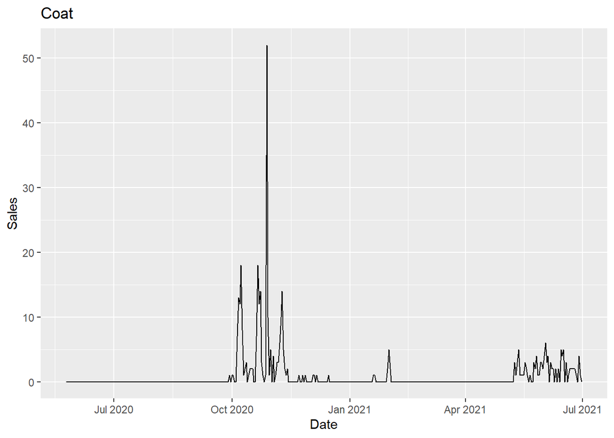

```r
ggplot(data_1, aes(x=event_date, y=sold_count)) + geom_line() + labs(title = "Coat") + ylab("Sales") + xlab("Date")
```

There were probably some stockout problems. Note that this product can be highly affected by seasons due to its nature. There is no need to use the data between Oct 2020 and Nov 2020 because that period represents another season. We only take the last part of the data into account.

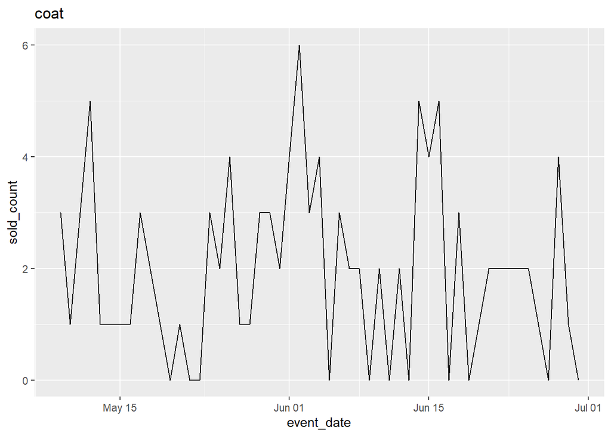

```r
data_1 = data_1[event_date>="2021-05-09"]
ggplot(data_1, aes(x=event_date, y=sold_count)) + geom_line() + labs(title = "coat")
```

Now, we cannot decompose the series at monthly level because we observe only 2 months. Therefore we use the function `decomp_limited()`.

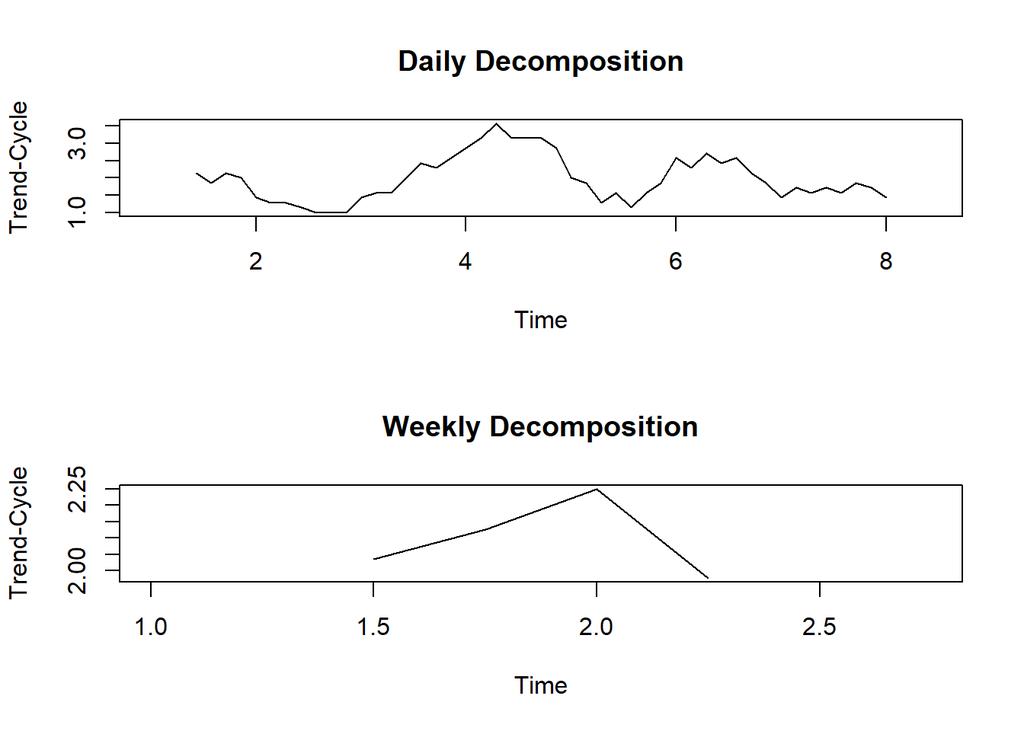

```r
dcmp_1 = decomp_limited(data = data_1)
plotdcmp_trend(dcmp_1)
```

Now the data is so limited that we cannot observe a trend-cycle component even for the weekly decomposition.

We can also check the seasonal components of the series.

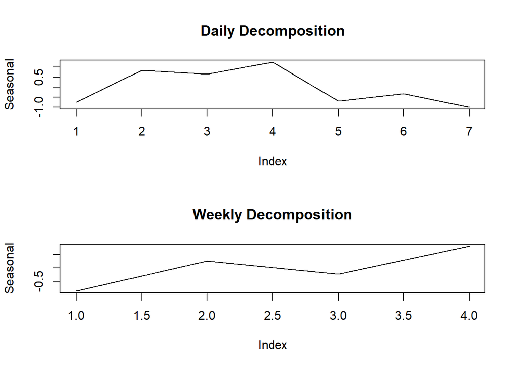

```r
plotdcmp_seasonal(dcmp_1)
```

At this point, we can try to model the random component of the daily decomposition with an ARIMA model. First we need to check the properties of the random component.

```r
random_1=dcmp_1$daily$random
data_1[,trend:=dcmp_1$daily$trend]
data_1[,seasonal:=dcmp_1$daily$seasonal]
data_1[,random:=random_1]
summary(ur.kpss(random_1))
```

```
##
## #######################
## # KPSS Unit Root Test #
## #######################
##
## Test is of type: mu with 3 lags.
##
## Value of test-statistic is: 0.0612
##
## Critical value for a significance level of:
##                 10pct  5pct 2.5pct  1pct
## critical values 0.347 0.463  0.574 0.739
```

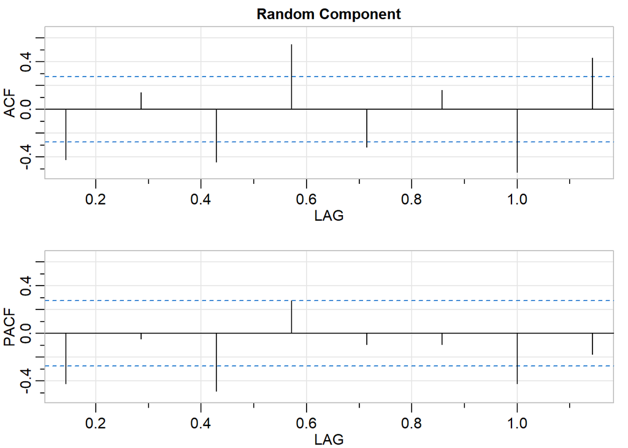

```
##       [,1]  [,2]  [,3] [,4]  [,5]  [,6]  [,7]  [,8]
## ACF  -0.43  0.14 -0.44 0.55 -0.32  0.16 -0.53  0.43
## PACF -0.43 -0.05 -0.49 0.27 -0.09 -0.10 -0.43 -0.18
```

```r
acf2(random_1, main="Random Component")
```

Now we try several ARIMA models.

```r
ar_1_1=arima(random_1, order=c(1,0,0))
ar_1_2=arima(random_1, order=c(2,0,0))
ma_1_1=arima(random_1, order=c(0,0,1))
ma_1_2=arima(random_1, order=c(0,0,2))
arma_1_1=arima(random_1, order=c(1,0,1))
arma_1_2=arima(random_1, order=c(1,0,2))
arma_1_3=arima(random_1, order=c(2,0,1))
arma_1_4=arima(random_1, order=c(2,0,2))
c(ar1=AIC(ar_1_1), ar2=AIC(ar_1_2), ma1=AIC(ma_1_1), ma2=AIC(ma_1_2), arma1=AIC(arma_1_1), arma2=AIC(arma_1_2), arma3=AIC(arma_1_3), arma4=AIC(arma_1_4))
```

```
##      ar1      ar2      ma1      ma2    arma1    arma2    arma3    arma4
## 139.9785 141.8362 134.1757 133.7986 132.8923 134.6321 134.2719 129.5322
```

ARIMA(2,0,2) provides the best AIC value. We can check their performance on the training data.

```r
data_1[,fitted_1_0:=random_1-ar_1_1$residuals+dcmp_1$daily$trend+dcmp_1$daily$seasonal]
data_1[,fitted_2_0:=random_1-ar_1_2$residuals+dcmp_1$daily$trend+dcmp_1$daily$seasonal]
data_1[,fitted_0_1:=random_1-ma_1_1$residuals+dcmp_1$daily$trend+dcmp_1$daily$seasonal]
data_1[,fitted_0_2:=random_1-ma_1_1$residuals+dcmp_1$daily$trend+dcmp_1$daily$seasonal]
data_1[,fitted_1_1:=random_1-arma_1_1$residuals+dcmp_1$daily$trend+dcmp_1$daily$seasonal]
data_1[,fitted_1_2:=random_1-arma_1_2$residuals+dcmp_1$daily$trend+dcmp_1$daily$seasonal]
data_1[,fitted_2_1:=random_1-arma_1_3$residuals+dcmp_1$daily$trend+dcmp_1$daily$seasonal]
data_1[,fitted_2_2:=random_1-arma_1_4$residuals+dcmp_1$daily$trend+dcmp_1$daily$seasonal]

melted_result=melt(data_1, c("event_date","sold_count"),
                   c("fitted_1_0","fitted_2_0", "fitted_0_1", "fitted_0_2",
                     "fitted_1_1","fitted_1_2", "fitted_2_1", "fitted_2_2"))

performance=melted_result[,accu_na(sold_count, value), by=list(variable)]
performance
```

```
##      variable  n     mean       sd        CV         FBias MAPE      RMSE
## 1: fitted_1_0 47 1.957447 1.587416 0.8109624  5.855921e-03  Inf 1.0041023
## 2: fitted_2_0 47 1.957447 1.587416 0.8109624  6.687412e-03  Inf 1.0025110
## 3: fitted_0_1 47 1.957447 1.587416 0.8109624 -9.206150e-03  Inf 0.9079645
## 4: fitted_0_2 47 1.957447 1.587416 0.8109624 -9.206150e-03  Inf 0.9079645
## 5: fitted_1_1 47 1.957447 1.587416 0.8109624 -7.662485e-04  Inf 0.8816879
## 6: fitted_1_2 47 1.957447 1.587416 0.8109624  1.348125e-05  Inf 0.8804635
## 7: fitted_2_1 47 1.957447 1.587416 0.8109624  4.782021e-04  Inf 0.8778704
## 8: fitted_2_2 47 1.957447 1.587416 0.8109624  1.846183e-03  Inf 0.8149702
##          MAD      MADP     WMAPE
## 1: 0.8361796 0.4271787 0.4271787
## 2: 0.8307289 0.4243941 0.4243941
## 3: 0.7150321 0.3652882 0.3652882
## 4: 0.7150321 0.3652882 0.3652882
## 5: 0.7127518 0.3641232 0.3641232
## 6: 0.7159806 0.3657727 0.3657727
## 7: 0.7154565 0.3655050 0.3655050
## 8: 0.6535447 0.3338761 0.3338761
```

ARIMA(2,0,2) provides the best result.

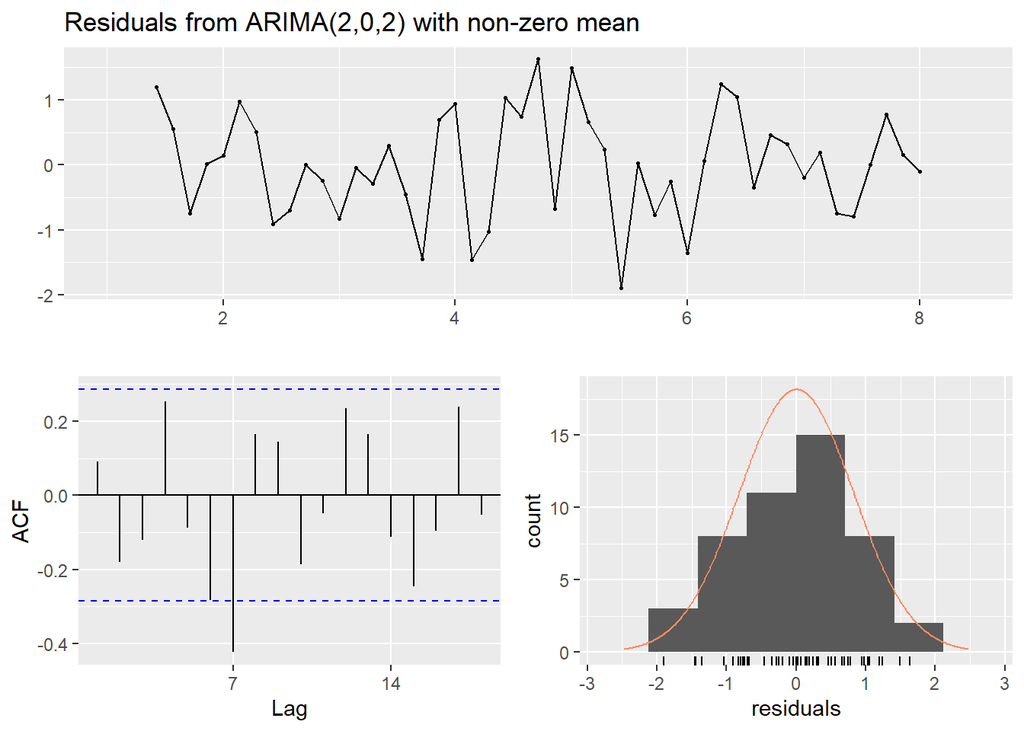

```
##
##  Ljung-Box test
##
## data:  Residuals from ARIMA(2,0,2) with non-zero mean
## Q* = 26.675, df = 6, p-value = 0.0001666
##
## Model df: 5.   Total lags used: 11
```

```r
checkresiduals(arma_1_4)
```

Now we can add some regressors to the model. Again note that these are lagged variables.

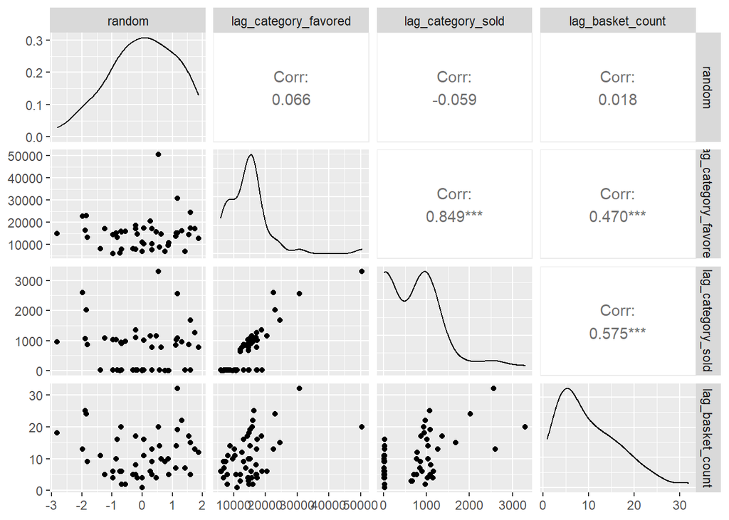

```r
ggpairs(data_1[,c("random","lag_category_favored","lag_category_sold","lag_basket_count")])
```

None of the lagged variables has significant effect. We cannot add those variables, instead we stick to the ARIMA model. Although it does not make much sense to check the measures without comparing it with another model, we can check those.

```r
results=vector('list',length(test_dates))
for(i in 1:length(test_dates)){
  current_date=test_dates[i]-forecast_ahead

  past_data=data_1[event_date<=current_date]
  forecast_data=data_1[event_date==test_dates[i]]

  # arima model
  frcst=arima(past_data[,ts(random)], order=c(2,0,2))
  frcst=forecast(frcst, h=forecast_ahead)
  forecast_data[,arima_prediction:=round(frcst$mean[2]+as.numeric(trend)+as.numeric(seasonal), 0)]

  results[[i]]=forecast_data
}
overall_results=rbindlist(results)
melted_result=melt(overall_results,c('event_date','sold_count'),
                     c('arima_prediction'))
performance= melted_result[,accu(sold_count,value),by=list(variable)]
performance
```

```
##            variable n     mean        sd        CV      FBias MAPE      RMSE
## 1: arima_prediction 7 1.571429 0.7867958 0.5006882 0.09090909  NaN 0.6546537
##          MAD      MADP     WMAPE
## 1: 0.4285714 0.2727273 0.2727273
```

## Product 2

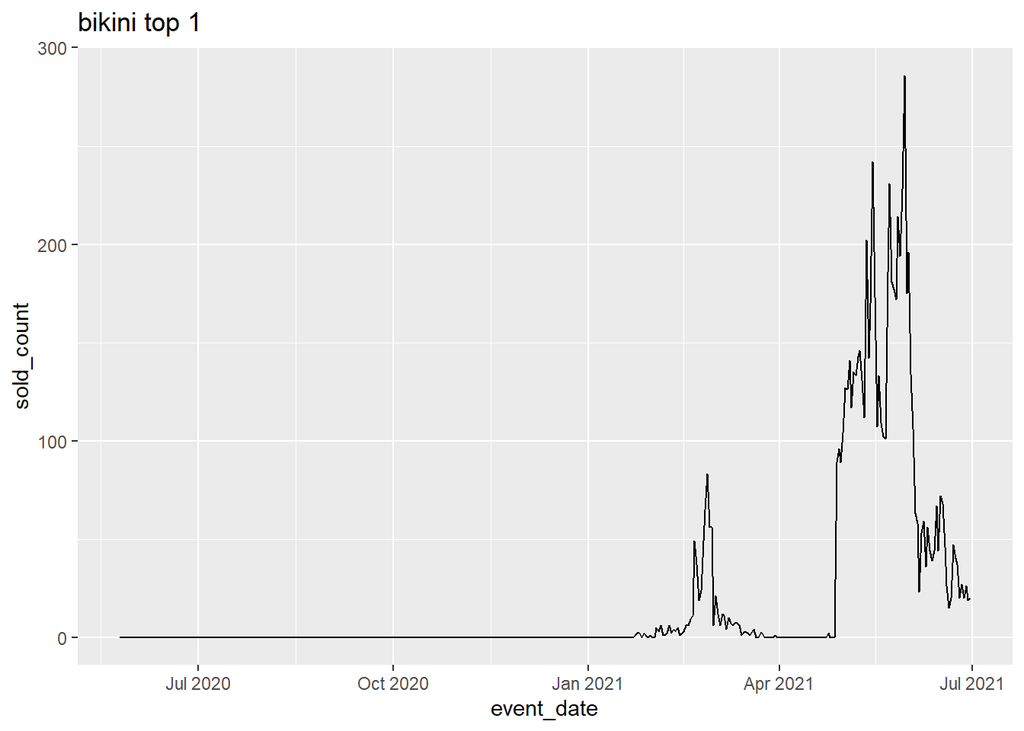

```r
ggplot(data_2, aes(x=event_date, y=sold_count)) + geom_line() + labs(title = "bikini top 1")
```

The data does not seem to be reliable until 2021-05-01, probably because of stockouts or production related problems. Therefore, only the last part of the time series will be used.

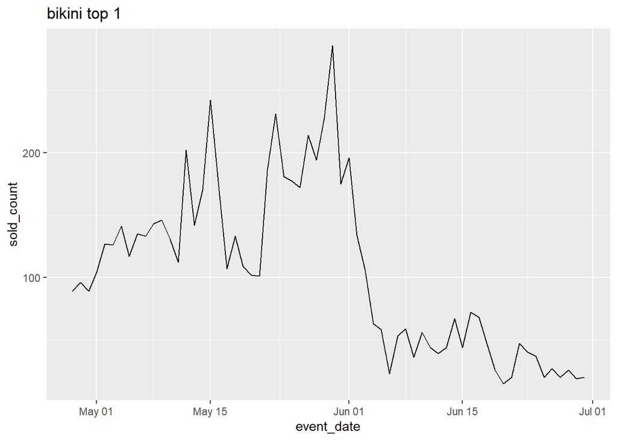

```r
data_2 = data_2[event_date>="2021-04-28"]
ggplot(data_2, aes(x=event_date, y=sold_count)) + geom_line() + labs(title = "bikini top 1")
```

Now, we cannot decompose the series at monthly level because we observe only 2 months. Therefore we use the function `decomp_limited()`.

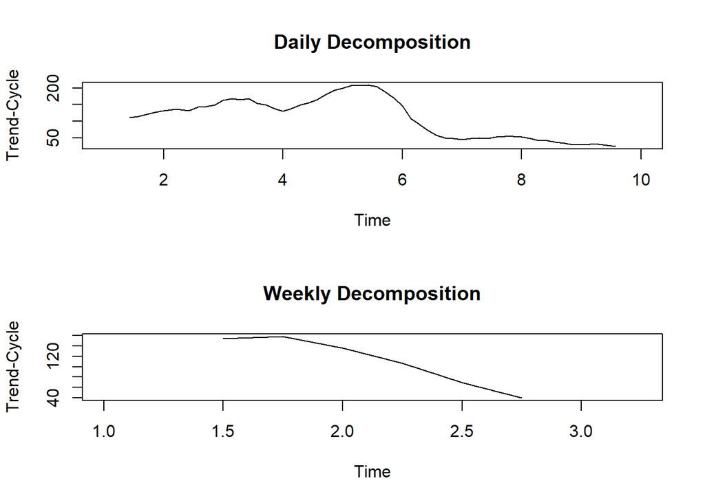

```r
dcmp_2 = decomp_limited(data = data_2)
plotdcmp_trend(dcmp_2)
```

We can also check the seasonal components of the series.

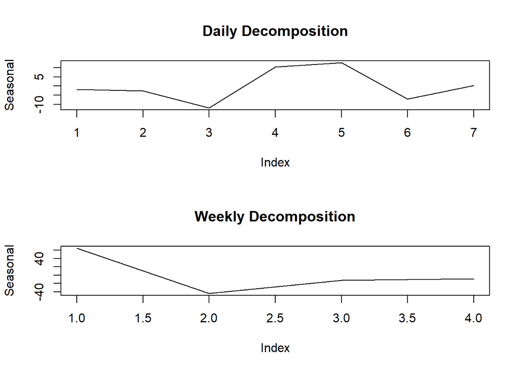

```r
plotdcmp_seasonal(dcmp_2)
```

At this point, we can try to model the random component of the daily decomposition with an ARIMA model. First we need to check the properties of the random component.

```r
random_2=dcmp_2$daily$random
data_2[,trend:=dcmp_2$daily$trend]
data_2[,seasonal:=dcmp_2$daily$seasonal]
data_2[,random:=random_2]
summary(ur.kpss(random_2))
```

```
##
## #######################
## # KPSS Unit Root Test #
## #######################
##
## Test is of type: mu with 3 lags.
##
## Value of test-statistic is: 0.0337
##
## Critical value for a significance level of:
##                 10pct  5pct 2.5pct  1pct
## critical values 0.347 0.463  0.574 0.739
```

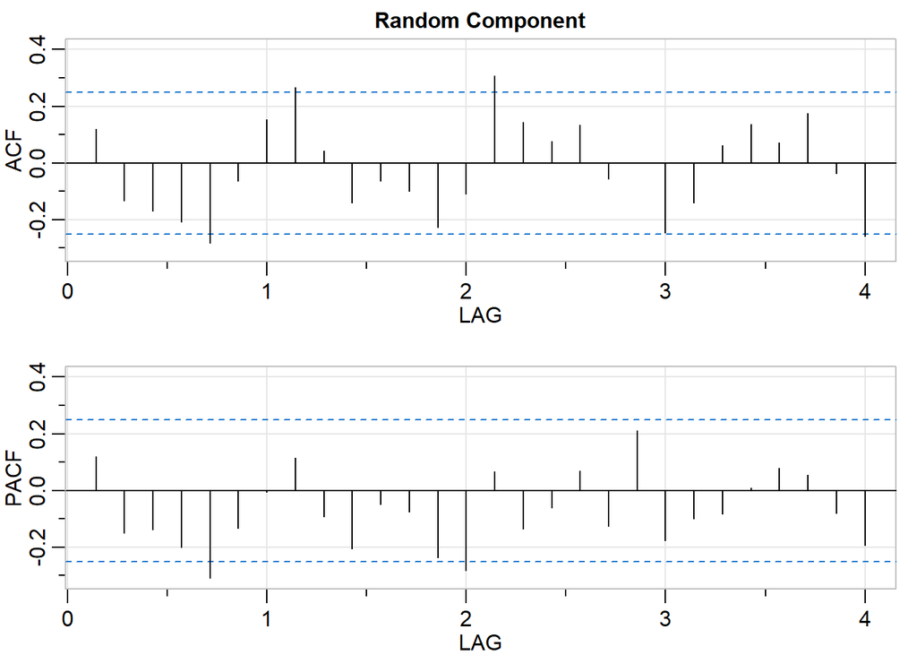

```
##      [,1]  [,2]  [,3]  [,4]  [,5]  [,6]  [,7] [,8]  [,9] [,10] [,11] [,12]
## ACF  0.12 -0.13 -0.17 -0.21 -0.28 -0.06  0.15 0.27  0.04 -0.14 -0.06 -0.10
## PACF 0.12 -0.15 -0.14 -0.20 -0.31 -0.13 -0.01 0.12 -0.09 -0.21 -0.05 -0.08
##      [,13] [,14] [,15] [,16] [,17] [,18] [,19] [,20] [,21] [,22] [,23] [,24]
## ACF  -0.23 -0.11  0.31  0.14  0.07  0.13 -0.06  0.00 -0.25 -0.14  0.06  0.14
## PACF -0.24 -0.28  0.07 -0.14 -0.06  0.07 -0.13  0.21 -0.18 -0.10 -0.08  0.01
##      [,25] [,26] [,27] [,28]
## ACF   0.07  0.18 -0.04 -0.26
## PACF  0.08  0.05 -0.08 -0.19
```

```r
acf2(random_2, main="Random Component")
```

The unit root test suggests that the series is stationary. We can try to fit different ARIMA models.

```r
ar_2_1=arima(random_2, order=c(1,0,0))
ar_2_2=arima(random_2, order=c(2,0,0))
ma_2_1=arima(random_2, order=c(0,0,1))
ma_2_2=arima(random_2, order=c(0,0,2))
arma_2_1=arima(random_2, order=c(1,0,1))
arma_2_2=arima(random_2, order=c(1,0,2))
arma_2_3=arima(random_2, order=c(2,0,1))
arma_2_4=arima(random_2, order=c(2,0,2))
c(ar1=AIC(ar_2_1), ar2=AIC(ar_2_2), ma1=AIC(ma_2_1), ma2=AIC(ma_2_2), arma1=AIC(arma_2_1), arma2=AIC(arma_2_2), arma3=AIC(arma_2_3), arma4=AIC(arma_2_4))
```

```
##      ar1      ar2      ma1      ma2    arma1    arma2    arma3    arma4
## 536.1441 536.8601 535.8757 537.0434 537.6729 529.0316 527.4513 528.5335
```

ARIMA(2,0,1) provides the best AIC value. We can check their performance on the training data.

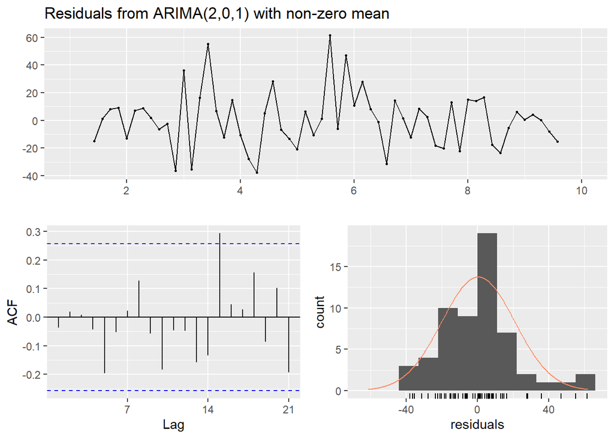

```
##
##  Ljung-Box test
##
## data:  Residuals from ARIMA(2,0,1) with non-zero mean
## Q* = 9.0435, df = 9, p-value = 0.4333
##
## Model df: 4.   Total lags used: 13
```

```r
checkresiduals(arma_2_3)
```

All assumptions on residuals seem to hold but the normality assumption is not that strong.

```r
data_2[,fitted_1_0:=random_2-ar_2_1$residuals+dcmp_2$daily$trend+dcmp_2$daily$seasonal]
data_2[,fitted_2_0:=random_2-ar_2_2$residuals+dcmp_2$daily$trend+dcmp_2$daily$seasonal]
data_2[,fitted_0_1:=random_2-ma_2_1$residuals+dcmp_2$daily$trend+dcmp_2$daily$seasonal]
data_2[,fitted_0_2:=random_2-ma_2_1$residuals+dcmp_2$daily$trend+dcmp_2$daily$seasonal]
data_2[,fitted_1_1:=random_2-arma_2_1$residuals+dcmp_2$daily$trend+dcmp_2$daily$seasonal]
data_2[,fitted_1_2:=random_2-arma_2_2$residuals+dcmp_2$daily$trend+dcmp_2$daily$seasonal]
data_2[,fitted_2_1:=random_2-arma_2_3$residuals+dcmp_2$daily$trend+dcmp_2$daily$seasonal]
data_2[,fitted_2_2:=random_2-arma_2_4$residuals+dcmp_2$daily$trend+dcmp_2$daily$seasonal]

melted_result=melt(data_2, c("event_date","sold_count"),
                   c("fitted_1_0","fitted_2_0", "fitted_0_1", "fitted_0_2",
                     "fitted_1_1","fitted_1_2", "fitted_2_1", "fitted_2_2"))

performance=melted_result[,accu_na(sold_count, value), by=list(variable)]
performance
```

```
##      variable  n     mean       sd        CV         FBias      MAPE     RMSE
## 1: fitted_1_0 58 110.3448 68.17973 0.6178788  3.308202e-04 0.2689282 23.36276
## 2: fitted_2_0 58 110.3448 68.17973 0.6178788 -6.220743e-05 0.2652383 23.09690
## 3: fitted_0_1 58 110.3448 68.17973 0.6178788  3.627599e-04 0.2664800 23.30684
## 4: fitted_0_2 58 110.3448 68.17973 0.6178788  3.627599e-04 0.2664800 23.30684
## 5: fitted_1_1 58 110.3448 68.17973 0.6178788  2.719873e-04 0.2676818 23.26567
## 6: fitted_1_2 58 110.3448 68.17973 0.6178788  4.058536e-03 0.2275515 20.72788
## 7: fitted_2_1 58 110.3448 68.17973 0.6178788  4.436676e-03 0.2172897 20.38082
## 8: fitted_2_2 58 110.3448 68.17973 0.6178788  5.009835e-03 0.2219791 20.14841
##         MAD      MADP     WMAPE
## 1: 18.17468 0.1647081 0.1647081
## 2: 18.00411 0.1631623 0.1631623
## 3: 18.20667 0.1649980 0.1649980
## 4: 18.20667 0.1649980 0.1649980
## 5: 18.25181 0.1654070 0.1654070
## 6: 15.44605 0.1399798 0.1399798
## 7: 15.33782 0.1389989 0.1389989
## 8: 15.47926 0.1402808 0.1402808
```

ARIMA(2,0,1) model provides the best result.

Now we can add some regressors to the model. Again note that these are lagged variables.

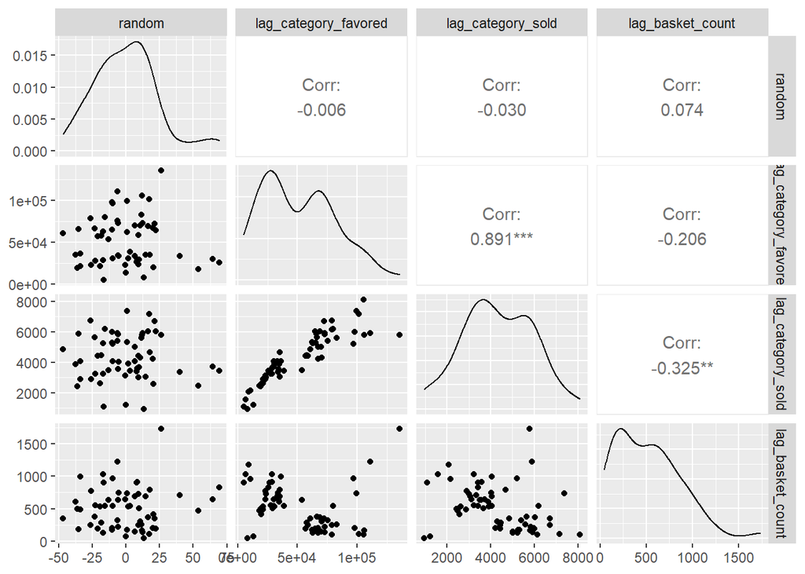

```r
ggpairs(data_2[,c("random","lag_category_favored","lag_category_sold","lag_basket_count")])
```

None of the lagged variables has significant effect. We cannot add those variables, instead we stick to the ARIMA model. Although it does not make much sense to check the measures without comparing it with another model, we can check those.

```r
results=vector('list',length(test_dates))
for(i in 1:length(test_dates)){
  current_date=test_dates[i]-forecast_ahead

  past_data=data_2[event_date<=current_date]
  forecast_data=data_2[event_date==test_dates[i]]

  # arima model
  frcst=arima(past_data[,ts(random)], order=c(2,0,1))
  frcst=forecast(frcst, h=forecast_ahead)
  forecast_data[,arima_prediction:=round(frcst$mean[2]+as.numeric(trend)+as.numeric(seasonal), 0)]

  results[[i]]=forecast_data
}
overall_results=rbindlist(results)
melted_result=melt(overall_results,c('event_date','sold_count'),
                     c('arima_prediction'))
performance= melted_result[,accu(sold_count,value),by=list(variable)]
performance
```

```
##            variable n     mean       sd        CV      FBias      MAPE     RMSE
## 1: arima_prediction 7 30.14286 11.15689 0.3701338 -0.1137441 0.2488677 7.855844
##    MAD      MADP     WMAPE
## 1:   6 0.1990521 0.1990521
```

## Product 3

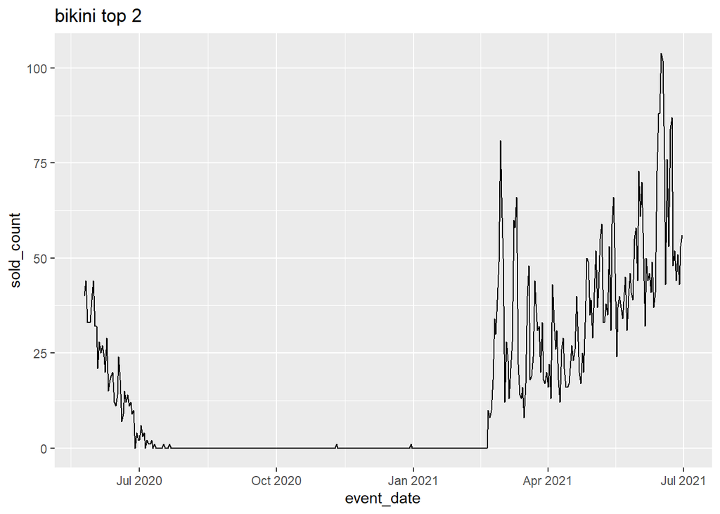

```r
ggplot(data_3, aes(x=event_date, y=sold_count)) + geom_line() + labs(title = "bikini top 2")
```

The data is not reliable until 2021-02-20, probably because of stockouts or production related problems.

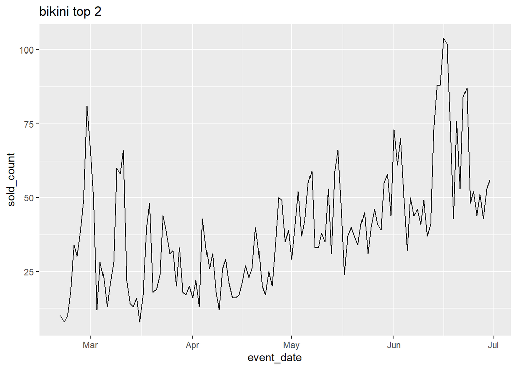

```r
data_3 = data_3[event_date>="2021-02-20"]
ggplot(data_3, aes(x=event_date, y=sold_count)) + geom_line() + labs(title = "bikini top 2")
```

Now, we cannot decompose the series at monthly level because we observe only 4 months. Therefore we use the function `decomp_limited()`.

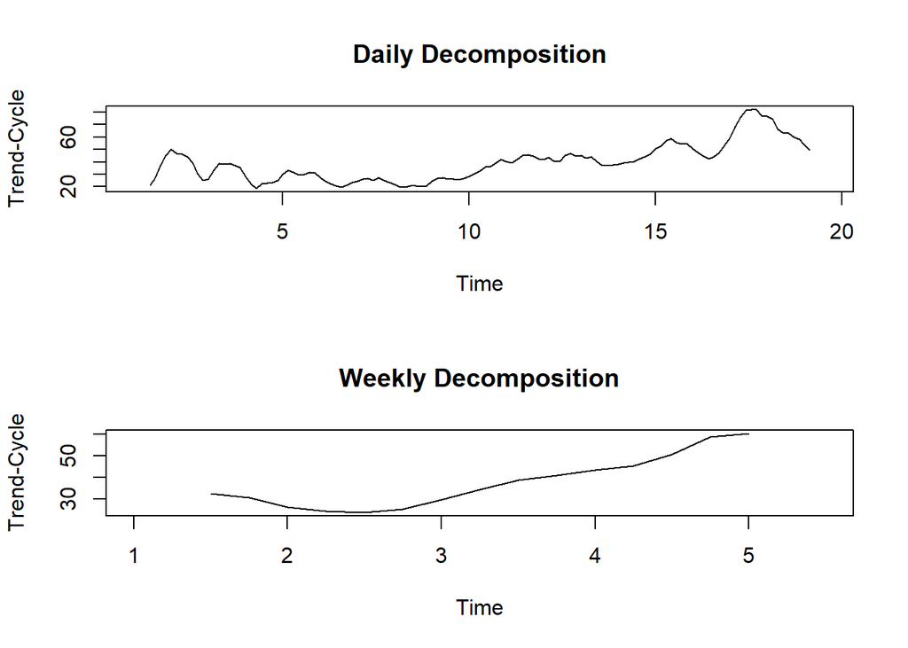

```r
dcmp_3 = decomp_limited(data = data_3)
plotdcmp_trend(dcmp_3)
```

Now the weekly decomposition provides smoother curve for trend-cycle component. First, it decreases slightly and increase afterwards.

We can also check the seasonal components of the series.

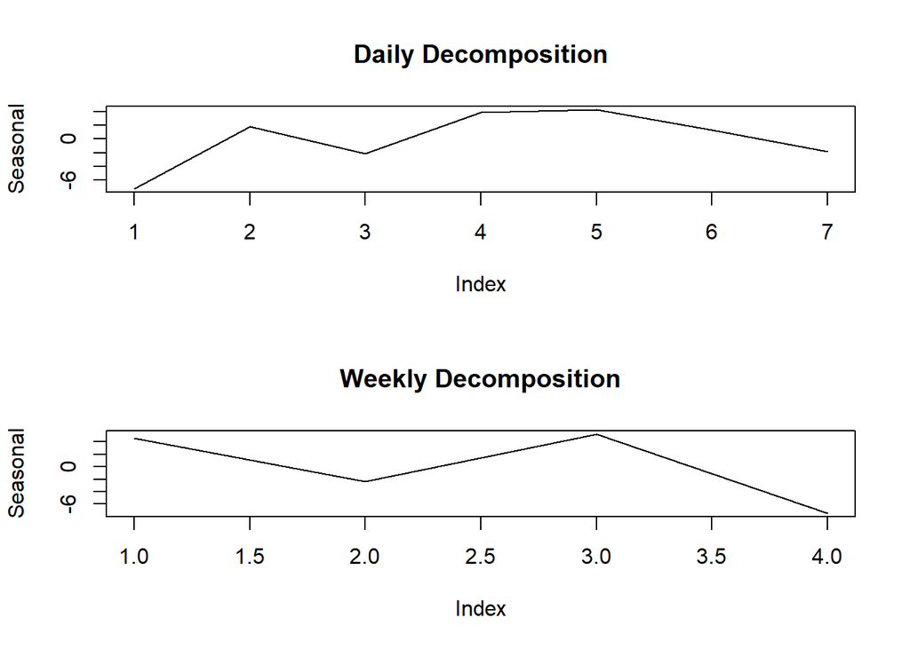

```r
plotdcmp_seasonal(dcmp_3)
```

At this point, we can try to model the random component of the daily decomposition with an ARIMA model. First we need to check the properties of the random component.

```r
random_3=dcmp_3$daily$random
data_3[,trend:=dcmp_3$daily$trend]
data_3[,seasonal:=dcmp_3$daily$seasonal]
data_3[,random:=random_3]
summary(ur.kpss(random_3))
```

```
##
## #######################
## # KPSS Unit Root Test #
## #######################
##
## Test is of type: mu with 4 lags.
##
## Value of test-statistic is: 0.0169
##
## Critical value for a significance level of:
##                 10pct  5pct 2.5pct  1pct
## critical values 0.347 0.463  0.574 0.739
```

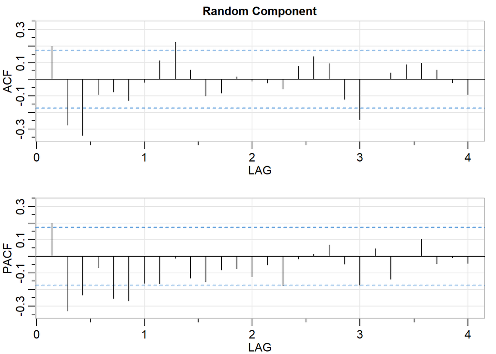

```
##      [,1]  [,2]  [,3]  [,4]  [,5]  [,6]  [,7]  [,8]  [,9] [,10] [,11] [,12]
## ACF   0.2 -0.28 -0.34 -0.09 -0.08 -0.13 -0.02  0.11  0.22  0.06 -0.10 -0.08
## PACF  0.2 -0.33 -0.23 -0.07 -0.26 -0.27 -0.16 -0.17 -0.01 -0.13 -0.15 -0.08
##      [,13] [,14] [,15] [,16] [,17] [,18] [,19] [,20] [,21] [,22] [,23] [,24]
## ACF   0.01 -0.01 -0.02 -0.06  0.08  0.14  0.09 -0.12 -0.24  0.00  0.04  0.09
## PACF -0.08 -0.12 -0.05 -0.18 -0.02  0.01  0.07 -0.05 -0.17  0.05 -0.14  0.00
##      [,25] [,26] [,27] [,28]
## ACF    0.1  0.06 -0.02 -0.09
## PACF   0.1 -0.05 -0.01 -0.04
```

```r
acf2(random_3, main="Random Component")
```

The unit root test suggests that the series is stationary. We can try to fit different ARIMA models.

```r
ar_3_1=arima(random_3, order=c(2,0,0))
ar_3_2=arima(random_3, order=c(3,0,0))
ma_3_1=arima(random_3, order=c(0,0,2))
ma_3_2=arima(random_3, order=c(0,0,3))
arma_3_1=arima(random_3, order=c(2,0,2))
arma_3_2=arima(random_3, order=c(2,0,3))
arma_3_3=arima(random_3, order=c(3,0,2))
arma_3_4=arima(random_3, order=c(3,0,3))
c(ar1=AIC(ar_3_1), ar2=AIC(ar_3_2), ma1=AIC(ma_3_1), ma2=AIC(ma_3_2), arma1=AIC(arma_3_1), arma2=AIC(arma_3_2), arma3=AIC(arma_3_3), arma4=AIC(arma_3_4))
```

```
##      ar1      ar2      ma1      ma2    arma1    arma2    arma3    arma4
## 939.9926 935.2124 926.9161 907.2205 904.8634 909.9338 908.5313 899.2499
```

ARIMA(3,0,3) provides the best AIC value. We can check their performance on the training data.

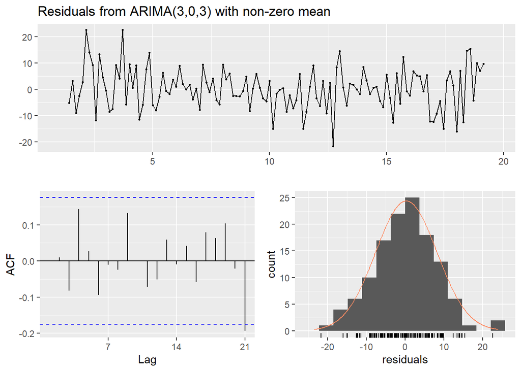

```
##
##  Ljung-Box test
##
## data:  Residuals from ARIMA(3,0,3) with non-zero mean
## Q* = 9.0193, df = 7, p-value = 0.2513
##
## Model df: 7.   Total lags used: 14
```

```r
checkresiduals(arma_3_4)
```

All assumptions on residuals seem to hold.

```r
data_3[,fitted_2_0:=random_3-ar_3_1$residuals+dcmp_3$daily$trend+dcmp_3$daily$seasonal]
data_3[,fitted_3_0:=random_3-ar_3_2$residuals+dcmp_3$daily$trend+dcmp_3$daily$seasonal]
data_3[,fitted_0_2:=random_3-ma_3_1$residuals+dcmp_3$daily$trend+dcmp_3$daily$seasonal]
data_3[,fitted_0_3:=random_3-ma_3_1$residuals+dcmp_3$daily$trend+dcmp_3$daily$seasonal]
data_3[,fitted_2_2:=random_3-arma_3_1$residuals+dcmp_3$daily$trend+dcmp_3$daily$seasonal]
data_3[,fitted_2_3:=random_3-arma_3_2$residuals+dcmp_3$daily$trend+dcmp_3$daily$seasonal]
data_3[,fitted_3_2:=random_3-arma_3_3$residuals+dcmp_3$daily$trend+dcmp_3$daily$seasonal]
data_3[,fitted_3_3:=random_3-arma_3_4$residuals+dcmp_3$daily$trend+dcmp_3$daily$seasonal]

melted_result=melt(data_3, c("event_date","sold_count"),
                   c("fitted_2_0","fitted_3_0", "fitted_0_2", "fitted_0_3",
                     "fitted_2_2","fitted_2_3", "fitted_3_2", "fitted_3_3"))

performance=melted_result[,accu_na(sold_count, value), by=list(variable)]
performance
```

```
##      variable   n   mean       sd        CV         FBias      MAPE      RMSE
## 1: fitted_2_0 125 39.584 20.01378 0.5056027  5.572839e-05 0.2543095 10.053940
## 2: fitted_3_0 125 39.584 20.01378 0.5056027 -5.609553e-04 0.2535087  9.778796
## 3: fitted_0_2 125 39.584 20.01378 0.5056027  1.040184e-02 0.2211590  9.384472
## 4: fitted_0_3 125 39.584 20.01378 0.5056027  1.040184e-02 0.2211590  9.384472
## 5: fitted_2_2 125 39.584 20.01378 0.5056027  9.575590e-03 0.1995369  8.281536
## 6: fitted_2_3 125 39.584 20.01378 0.5056027  8.016240e-03 0.2071041  8.561118
## 7: fitted_3_2 125 39.584 20.01378 0.5056027  9.316193e-03 0.2112515  8.500089
## 8: fitted_3_3 125 39.584 20.01378 0.5056027  7.589395e-03 0.1911333  7.889903
##         MAD      MADP     WMAPE
## 1: 7.780844 0.1965654 0.1965654
## 2: 7.803252 0.1971315 0.1971315
## 3: 6.975989 0.1762325 0.1762325
## 4: 6.975989 0.1762325 0.1762325
## 5: 6.477844 0.1636480 0.1636480
## 6: 6.682008 0.1688058 0.1688058
## 7: 6.756580 0.1706897 0.1706897
## 8: 6.204884 0.1567523 0.1567523
```

ARIMA(3,0,3) model provides the best result.

Now we can add some regressors to the model. Again note that these are lagged variables.

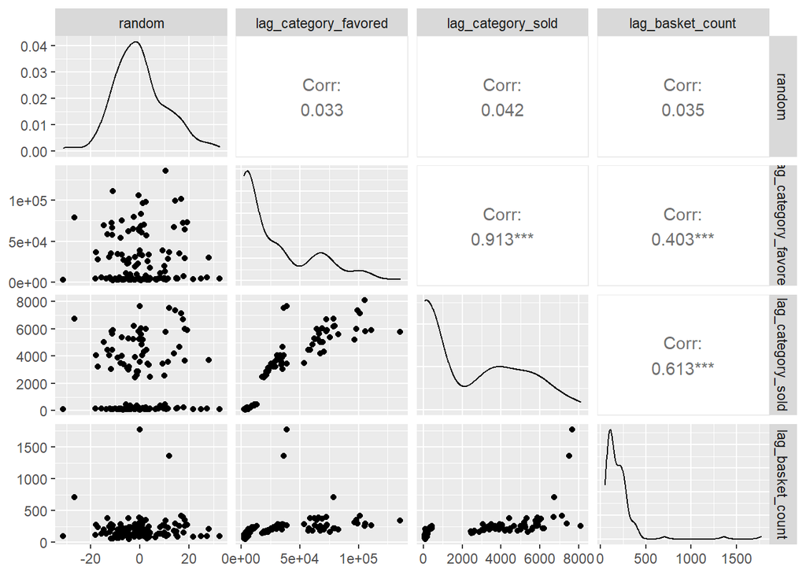

```r
ggpairs(data_3[,c("random","lag_category_favored","lag_category_sold","lag_basket_count")])
```

None of the lagged variables has significant effect. We cannot add those variables, instead we stick to the ARIMA model. Although it does not make much sense to check the measures without comparing it with another model, we can check those.

```r
results=vector('list',length(test_dates))
for(i in 1:length(test_dates)){
  current_date=test_dates[i]-forecast_ahead

  past_data=data_3[event_date<=current_date]
  forecast_data=data_3[event_date==test_dates[i]]

  # arima model
  frcst=arima(past_data[,ts(random)], order=c(3,0,3))
  frcst=forecast(frcst, h=forecast_ahead)
  forecast_data[,arima_prediction:=round(frcst$mean[2]+as.numeric(trend)+as.numeric(seasonal), 0)]

  results[[i]]=forecast_data
}
overall_results=rbindlist(results)
melted_result=melt(overall_results,c('event_date','sold_count'),
                     c('arima_prediction'))
performance= melted_result[,accu(sold_count,value),by=list(variable)]
performance
```

```
##            variable n     mean       sd        CV      FBias      MAPE     RMSE
## 1: arima_prediction 7 59.85714 17.78978 0.2972039 0.05966587 0.2077878 13.41108
##         MAD      MADP     WMAPE
## 1: 12.42857 0.2076372 0.2076372
```

## Product 4

The plot of the series is shown below.

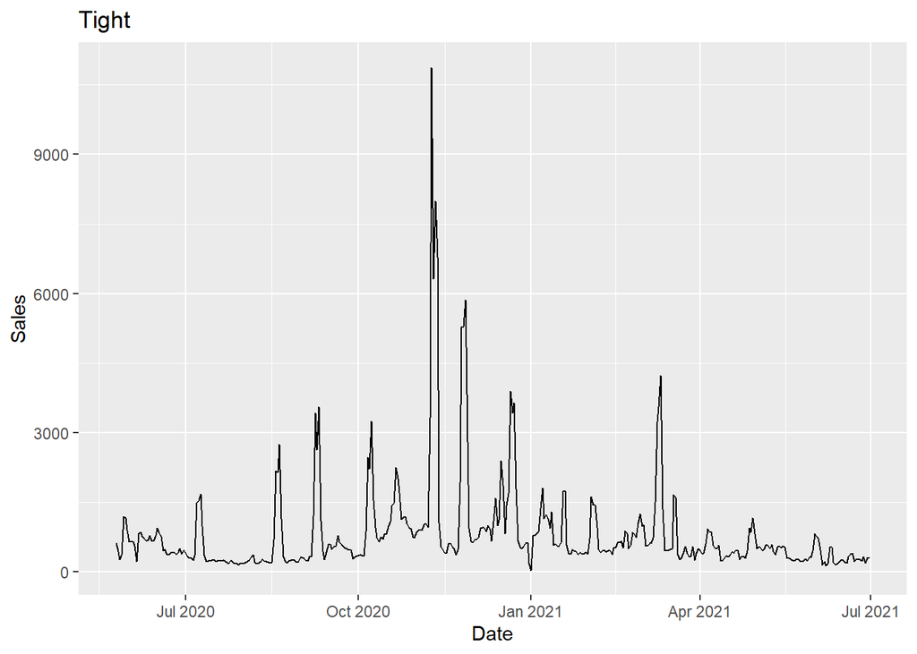

```r
ggplot(data_4, aes(x=event_date, y=sold_count)) + geom_line() + labs(title = "Tight") + ylab("Sales") + xlab("Date")
```

Some of these points cannot be explained by seasonality or trend only, we may need other regressors.

Now, we decompose the series using the predefined function `decomp()`.

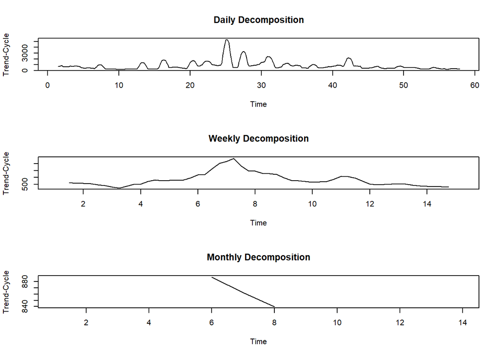

```r
dcmp_4 = decomp(data = data_4)
plotdcmp_trend(dcmp_4)
```

We can see that weekly trend-cycle component smoothes the series better. We see an increase in the 6th month and a decrease in the 7th month. Monthly decomposition is meaningless as stated before since there are only 14 months. Instead, we can check monthly aggregated data.

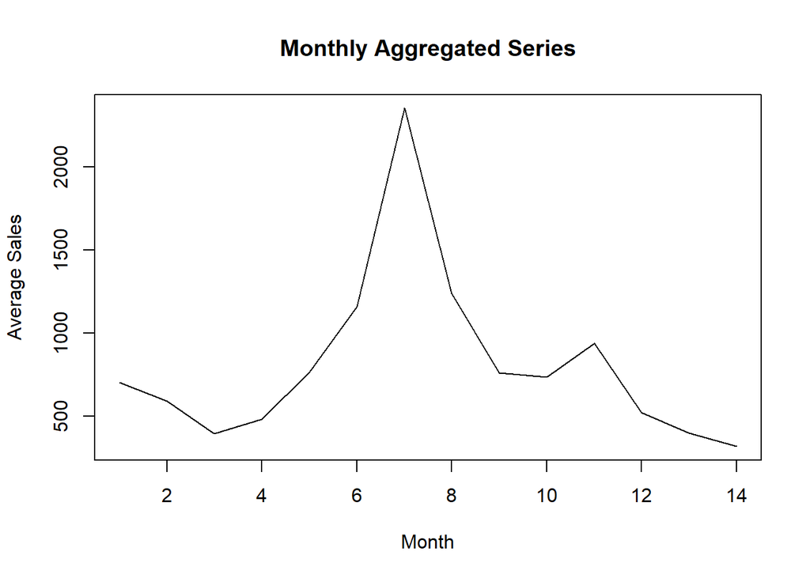

```r
plot(dcmp_4$monthly$aggregated, type="l", xlab="Month", ylab="Average Sales", main="Monthly Aggregated Series")
```

This is even smoother now. We can also check the seasonal components of the series.

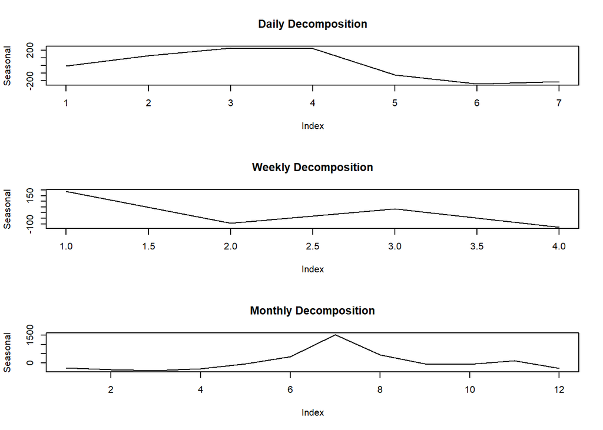

```r
plotdcmp_seasonal(dcmp_4)
```

We see that the second, the third, and the fourth days of the week, sales volume is larger. Note that the first day of the week corresponds to Monday. In addition to this, sales volume is larger in the first week of the month, but this result is not so reliable because of the approximation discussed earlier. Monthly seasonality effect is not so reliable either because it is not an actual decomposition (see the earlier discussion on this). But we see that sales volume is larger in the summer.

At this point, we can try to model the random component of the daily decomposition with an ARIMA model. First we need to check the properties of the random component.

```r
random_4=dcmp_4$daily$random
data_4[,trend:=dcmp_4$daily$trend]
data_4[,seasonal:=dcmp_4$daily$seasonal]
data_4[,random:=random_4]
summary(ur.kpss(random_4))
```

```
##
## #######################
## # KPSS Unit Root Test #
## #######################
##
## Test is of type: mu with 5 lags.
##
## Value of test-statistic is: 0.0063
##
## Critical value for a significance level of:
##                 10pct  5pct 2.5pct  1pct
## critical values 0.347 0.463  0.574 0.739
```

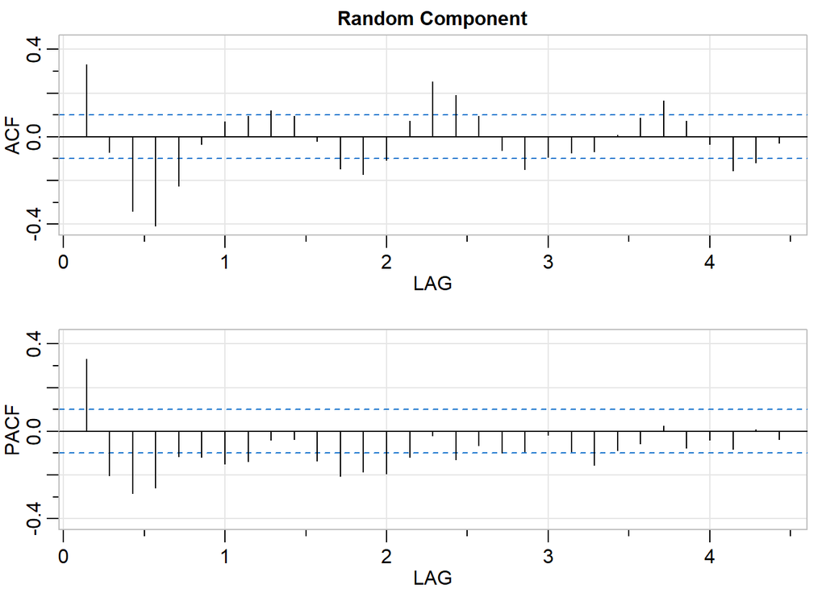

```
##      [,1]  [,2]  [,3]  [,4]  [,5]  [,6]  [,7]  [,8]  [,9] [,10] [,11] [,12]
## ACF  0.33 -0.07 -0.34 -0.41 -0.23 -0.03  0.07  0.09  0.12  0.09 -0.02 -0.15
## PACF 0.33 -0.20 -0.29 -0.26 -0.12 -0.12 -0.15 -0.14 -0.04 -0.04 -0.14 -0.21
##      [,13] [,14] [,15] [,16] [,17] [,18] [,19] [,20] [,21] [,22] [,23] [,24]
## ACF  -0.17 -0.11  0.07  0.25  0.19  0.09 -0.06 -0.15 -0.09 -0.07 -0.07  0.01
## PACF -0.19 -0.19 -0.12 -0.02 -0.13 -0.07 -0.10 -0.09 -0.02 -0.09 -0.15 -0.09
##      [,25] [,26] [,27] [,28] [,29] [,30] [,31]
## ACF   0.09  0.16  0.07 -0.04 -0.15 -0.12 -0.03
## PACF -0.06  0.02 -0.08 -0.04 -0.08  0.01 -0.04
```

```r
acf2(random_4, main="Random Component")
```

It can be assumed stationary and ACF and PACF suggest that there is some level of dependency among the observations. ARIMA model can catch these. MA model is not suitable for this series but AR model may be suitable. We can try couple of models and compare them based on AIC values.

```r
ar_4_1=arima(random_4, order=c(3,0,0))
ar_4_2=arima(random_4, order=c(4,0,0))
ar_4_3=arima(random_4, order=c(5,0,0))
arma_4_1=arima(random_4, order=c(3,0,1))
arma_4_2=arima(random_4, order=c(4,0,1))
arma_4_3=arima(random_4, order=c(5,0,1))
c(ar1=AIC(ar_4_1), ar2=AIC(ar_4_2), ar3=AIC(ar_4_3), arma1=AIC(arma_4_1), arma2=AIC(arma_4_2), arma3=AIC(arma_4_3))
```

```
##      ar1      ar2      ar3    arma1    arma2    arma3
## 6056.687 6030.952 6027.726 5944.317 5945.352 5947.351
```

ARIMA(3,0,1) provides the best AIC value. We can check their performance on the training data.

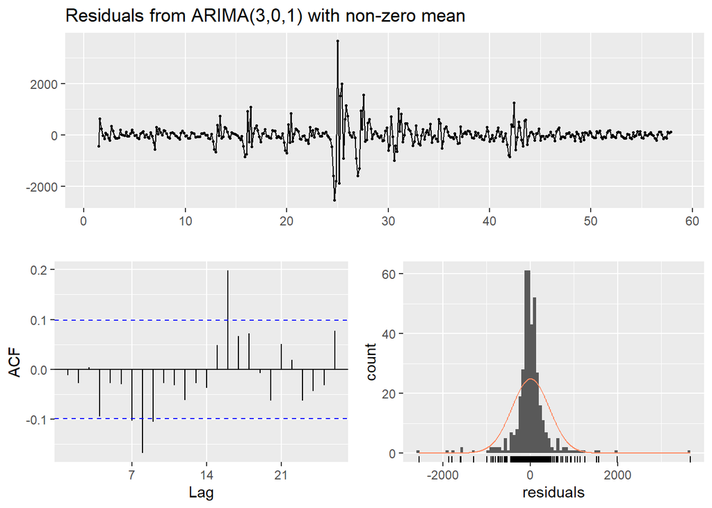

```
##
##  Ljung-Box test
##
## data:  Residuals from ARIMA(3,0,1) with non-zero mean
## Q* = 28.147, df = 9, p-value = 0.0009015
##
## Model df: 5.   Total lags used: 14
```

```r
checkresiduals(arma_4_1)
```

Assumptions are not strongly hold. Nevertheless, we cannot improve them at this point.

```r
data_4[,fitted_3_0:=random_4-ar_4_1$residuals+dcmp_4$daily$trend+dcmp_4$daily$seasonal]
data_4[,fitted_4_0:=random_4-ar_4_2$residuals+dcmp_4$daily$trend+dcmp_4$daily$seasonal]
data_4[,fitted_5_0:=random_4-ar_4_3$residuals+dcmp_4$daily$trend+dcmp_4$daily$seasonal]
data_4[,fitted_3_1:=random_4-arma_4_1$residuals+dcmp_4$daily$trend+dcmp_4$daily$seasonal]
data_4[,fitted_4_1:=random_4-arma_4_2$residuals+dcmp_4$daily$trend+dcmp_4$daily$seasonal]
data_4[,fitted_5_1:=random_4-arma_4_3$residuals+dcmp_4$daily$trend+dcmp_4$daily$seasonal]

melted_result=melt(data_4, c("event_date","sold_count"),
                   c("fitted_3_0","fitted_4_0", "fitted_5_0", "fitted_3_1",
                     "fitted_4_1","fitted_5_1"))

performance=melted_result[,accu_na(sold_count, value), by=list(variable)]
performance
```

```
##      variable   n     mean       sd       CV         FBias      MAPE     RMSE
## 1: fitted_3_0 396 825.0455 1074.228 1.302023  0.0007751898 0.3915949 500.2882
## 2: fitted_4_0 396 825.0455 1074.228 1.302023  0.0010292889 0.3993123 482.9018
## 3: fitted_5_0 396 825.0455 1074.228 1.302023  0.0010226867 0.4029410 479.6874
## 4: fitted_3_1 396 825.0455 1074.228 1.302023 -0.0003606484 0.3771218 429.8900
## 5: fitted_4_1 396 825.0455 1074.228 1.302023 -0.0003660731 0.3809992 429.3098
## 6: fitted_5_1 396 825.0455 1074.228 1.302023 -0.0003665681 0.3809848 429.3092
##         MAD      MADP     WMAPE
## 1: 257.2596 0.3118126 0.3118126
## 2: 258.6465 0.3134936 0.3134936
## 3: 258.7065 0.3135664 0.3135664
## 4: 234.2334 0.2839036 0.2839036
## 5: 235.9206 0.2859486 0.2859486
## 6: 235.9165 0.2859437 0.2859437
```

We see that ARIMA(3,0,1) gives the best result.

Now we can add some regressors to the model. Again note that these are lagged variables.

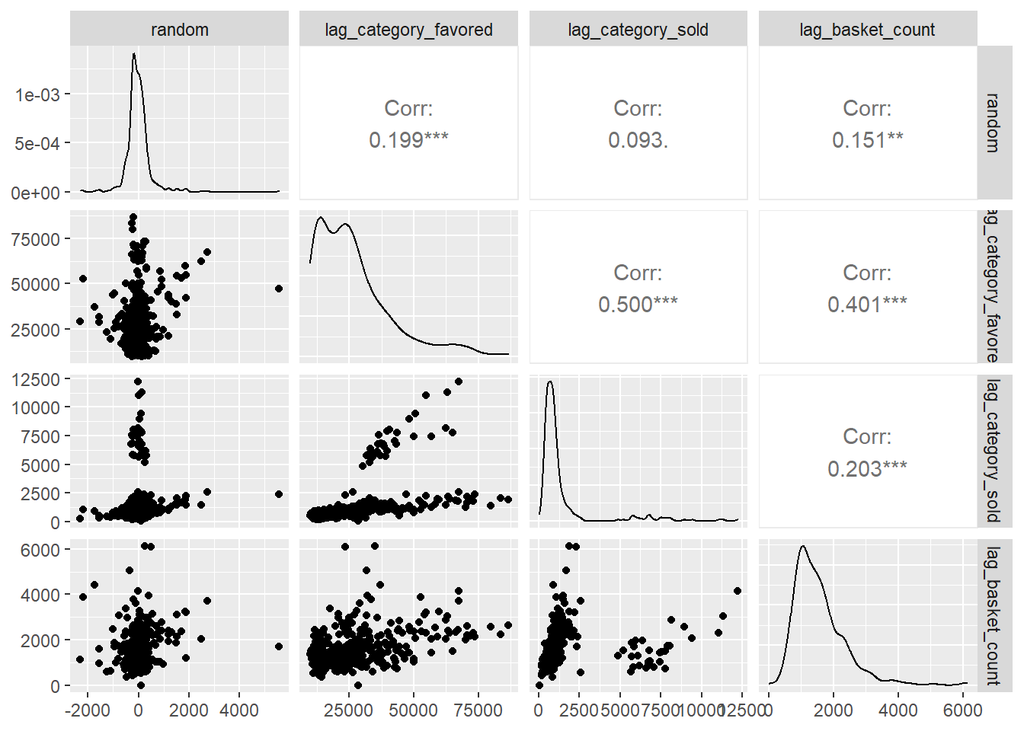

```r
ggpairs(data_4[,c("random","lag_category_favored","lag_category_sold","lag_basket_count")])
```

`lag_category_favored` seems to be the most important one but it may not be reliable because it depends on the whole category of products. Instead, we can use `lag_basket_count`.

```r
lm_4=lm(random~lag_basket_count, data=data_4)
summary(lm_4)
```

```
##
## Call:
## lm(formula = random ~ lag_basket_count, data = data_4)
##
## Residuals:
##     Min      1Q  Median      3Q     Max
## -2441.2  -227.9   -38.9   170.1  5539.5
##
## Coefficients:
##                    Estimate Std. Error t value Pr(>|t|)
## (Intercept)      -166.67968   62.20677  -2.679  0.00768 **
## lag_basket_count    0.10870    0.03577   3.039  0.00254 **
## ---
## Signif. codes:  0 '***' 0.001 '**' 0.01 '*' 0.05 '.' 0.1 ' ' 1
##
## Residual standard error: 560.8 on 394 degrees of freedom
##   (6 observations deleted due to missingness)
## Multiple R-squared:  0.0229, Adjusted R-squared:  0.02042
## F-statistic: 9.232 on 1 and 394 DF,  p-value: 0.002536
```

It is somehow significant but R-squared value is too small. Nevertheless we can try to add this variable to the ARIMA(3,0,1) model.

Now we compare ARIMA(3,0,1) and the new ARIMAX model on the test period defined earlier.

```r
results=vector('list',length(test_dates))
for(i in 1:length(test_dates)){
  current_date=test_dates[i]-forecast_ahead

  past_data=data_4[event_date<=current_date]
  forecast_data=data_4[event_date==test_dates[i]]

  # arima model
  frcst=arima(past_data[,ts(random)], order=c(3,0,1))
  frcst=forecast(frcst, h=forecast_ahead)
  forecast_data[,arima_prediction:=round(frcst$mean[2]+as.numeric(trend)+as.numeric(seasonal), 0)]

  # arimax model
  reg = matrix(past_data[,lag_basket_count], ncol=1)
  frcst=auto.arima(past_data[,ts(random)],max.p=3,start.p=3,max.q=1,start.q=1,xreg=reg,seasonal=FALSE,stepwise=FALSE,approximation=FALSE)
  reg = matrix(past_data[(.N-1):.N, basket_count], ncol=1)
  frcst=forecast(frcst, h=forecast_ahead, xreg=reg)
  forecast_data[,arimax_prediction:=round(frcst$mean[2]+as.numeric(trend)+as.numeric(seasonal), 0)]

  results[[i]]=forecast_data
}
overall_results=rbindlist(results)
melted_result=melt(overall_results,c('event_date','sold_count'),
                     c('arima_prediction','arimax_prediction'))
performance= melted_result[,accu(sold_count,value),by=list(variable)]
performance
```

```
##             variable n mean       sd        CV        FBias      MAPE     RMSE
## 1:  arima_prediction 7  280 56.91807 0.2032788 -0.005102041 0.3881944 109.5106
## 2: arimax_prediction 7  280 56.91807 0.2032788 -0.015306122 0.4206717 122.2071
##         MAD      MADP     WMAPE
## 1: 101.4286 0.3622449 0.3622449
## 2: 113.7143 0.4061224 0.4061224
```

Measures indicate that ARIMA(3,0,1) gives better results than ARIMAX gives.

## Product 5

The plot of the series is shown below.

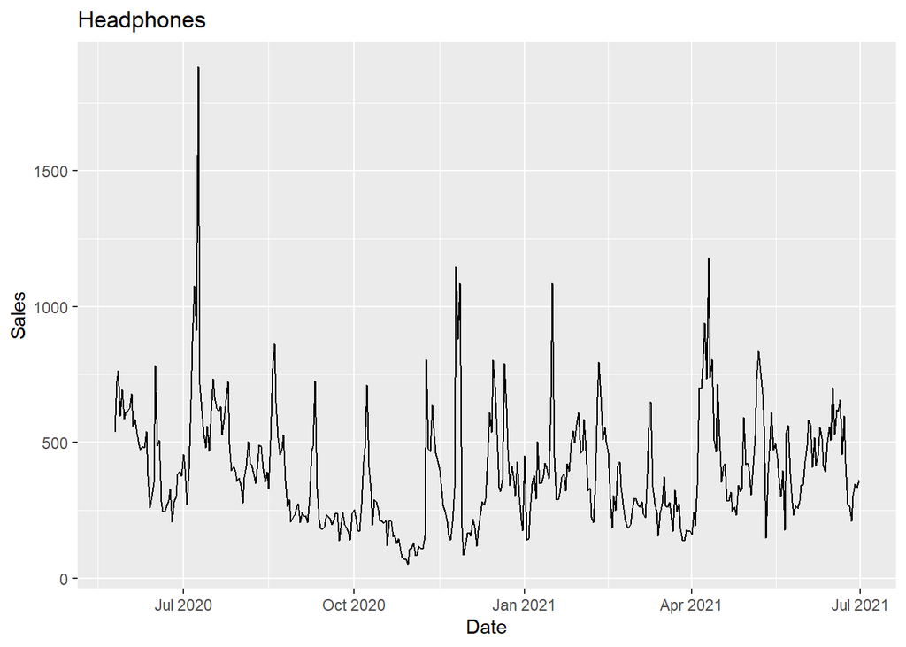

```r
ggplot(data_5, aes(x=event_date, y=sold_count)) + geom_line() + labs(title = "Headphones") + ylab("Sales") + xlab("Date")
```

Similar to the previous products, some of these points cannot be explained by seasonality or trend only, we may need other regressors.

Now, we decompose the series using function `decomp()`.

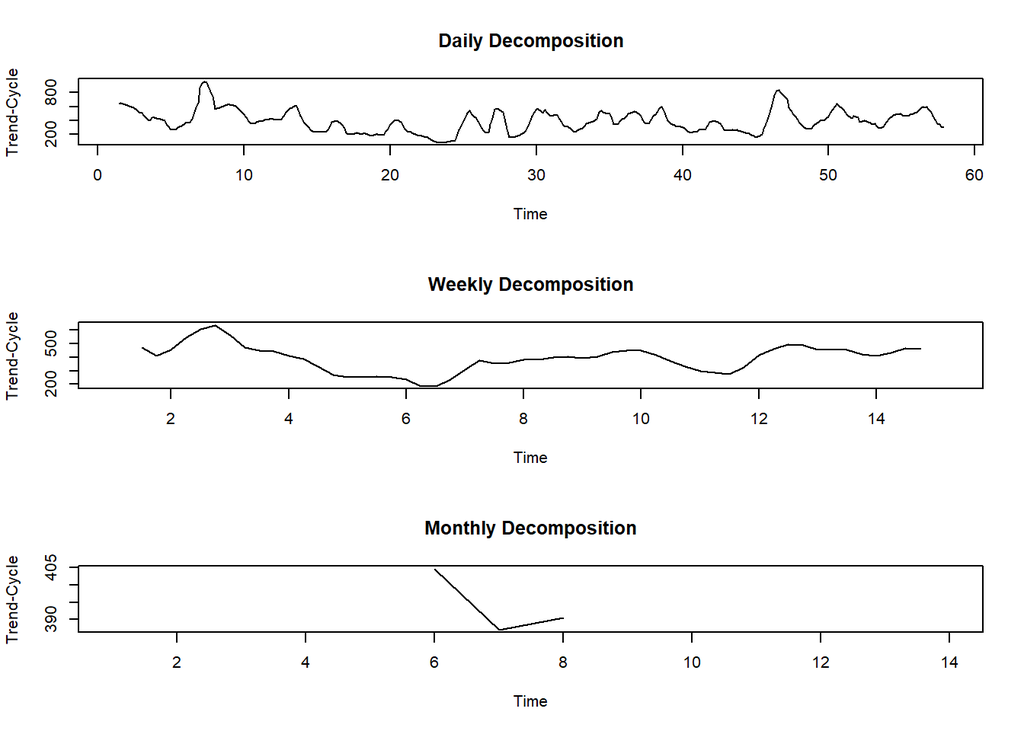

```r
dcmp_5 = decomp(data = data_5)
plotdcmp_trend(dcmp_5)
```

Weekly decomposition provides smoother curve. There is not an obvious trend. The series fluctuates. Also note that monthly decomposition does not make sense again. We can still check the aggregated data visually.

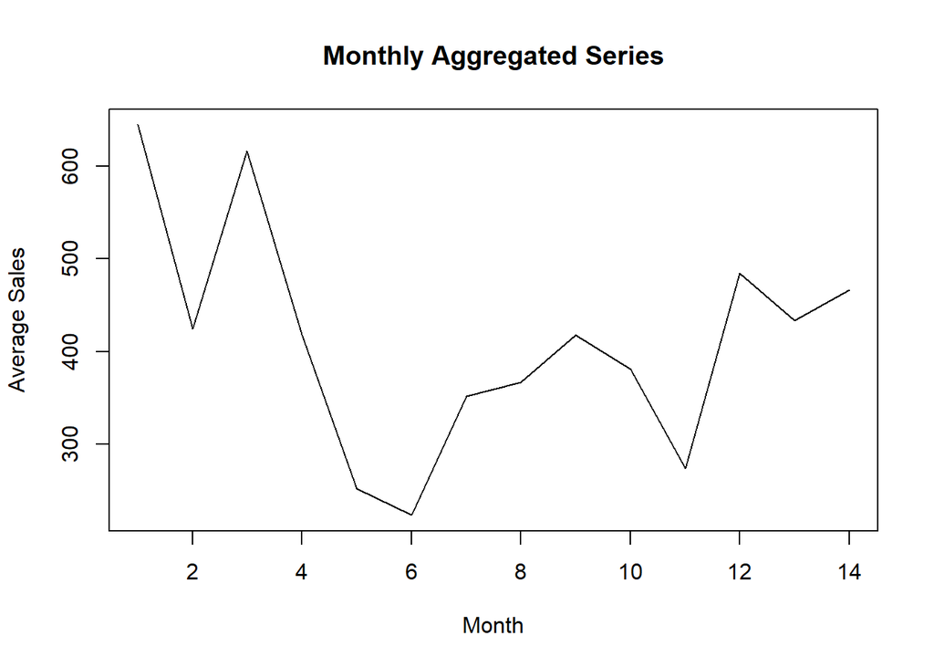

```r
plot(dcmp_5$monthly$aggregated, type="l", xlab="Month", ylab="Average Sales", main="Monthly Aggregated Series")
```

Monthly aggregated data is even smoother. We can also check the seasonal components of the series.

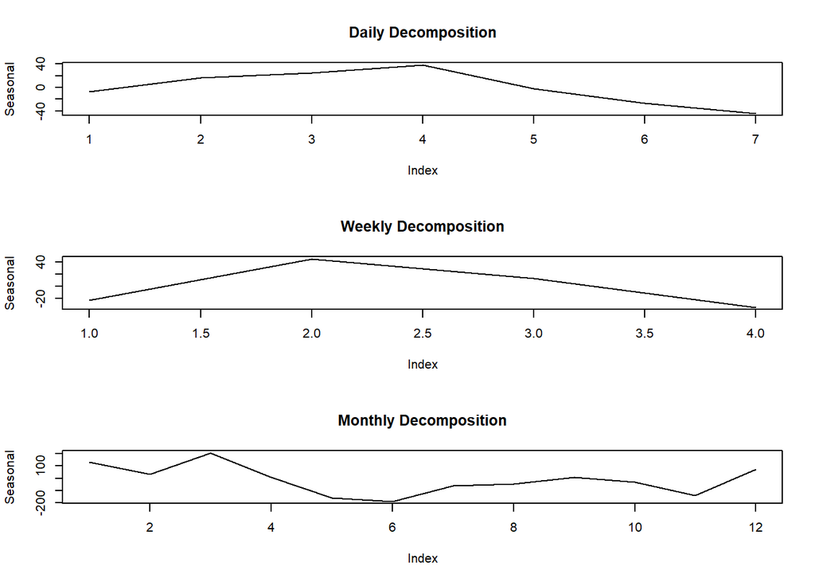

```r
plotdcmp_seasonal(dcmp_5)
```

In general, the largest sales volume is observed on day 4 of the week which corresponds to Thursday. On the other hand, the smallest sales volume is observed on Sunday, generally. Weekly decomposition is not trustable, but it shows approximately how the week of the month affects the sales. The first and the last week of the month have the smallest sales. Lastly, the sales volume tends to be larger in the spring and the winter. Monthly discussion is not too trustable as well (see earlier discussion).